# Net benefits of a mutualism: Influence of the quality of extrafloral nectar on the colony fitness of a mutualistic ant - Calixto - - Biotropica - Wiley Online Library

[figure not shown]

ORIGINAL ARTICLE

# Net benefits of a mutualism: Influence of the quality of extrafloral nectar on the colony fitness of a mutualistic ant

[Eduardo Soares Calixto](https://onlinelibrary.wiley.com/action/doSearch?ContribAuthorStored=Calixto%2C+Eduardo+Soares)

[Denise Lange](https://onlinelibrary.wiley.com/action/doSearch?ContribAuthorStored=Lange%2C+Denise)

[Kleber Del‐Claro](https://onlinelibrary.wiley.com/action/doSearch?ContribAuthorStored=Del-Claro%2C+Kleber)

First published: 08 February 2021

https://doi.org/10.1111/btp.12925

Associate Editor: Jennifer Powers

Handling Editor: Xavier Arnan

## Abstract

### Aim

Extrafloral nectar, a carbohydrate‐rich liquid, is the main plant‐based resource offered in exchange for ant protection. The positive results of this protection provided by ants are widely studied and supported; however, studies showing the benefits that ants and their colonies have from the resources offered by plants such as extrafloral nectar are scarce. Here, we evaluated how extrafloral nectar and artificial food resources with different nutrient concentration benefit short‐ and long‐term *Camponotus crassus* colony fitness (number and weight of individuals) and survival.

### Methods

We conducted two sets of experiments: (1) in the field we attached artificial ant nests to plants with clogged and unclogged extrafloral nectaries; and (2) in the laboratory we offered artificial food resources with different carbohydrate–protein ratios to ant colonies. With these experiments, we evaluated the number and weight of queens, adult workers, pupae, larvae, and eggs, as well as the survival probability of the colonies.

### Results

In the first experiment, the short‐term provision of extrafloral nectar resulted in a larger number and weight of individuals with access to this resource. In the second experiment, regardless of time, the supply of more concentrated carbohydrate and nitrogen food increased ant colony fitness and survival. Conclusion: We provided new evidence that extrafloral nectar significantly benefits ant colonies. Our results corroborate the assertion that these relationships are reciprocally beneficial.

## 1 INTRODUCTION

The ant–plant protective mutualism mediated by the production of extrafloral nectar is a common relationship worldwide (Calixto et al., 2018, 2020; Del‐Claro et al., 2016). Many studies have shown clear evidence of the benefits provided by associated ants to plants (Rosumek et al., 2009; Trager et al., 2010). By aggressively patrolling extrafloral nectary (EFN)‐bearing plants and removing potential herbivores, ants can increase plant fitness by reducing leaf area loss and increasing seed set production (Nascimento & Del‐Claro, 2010; Rosumek et al., 2009; Trager et al., 2010). However, this is only one side of the mutualism. The other side, the benefit gained by ants and their respective colonies that feed on extrafloral nectar, is poorly evaluated.

Extrafloral nectar is a liquid rich in mono and disaccharides (González‐Teuber & Heil, 2009; Nicolson & Thornburg, 2007), which has been suggested to be a fundamental resource for foliage‐dwelling ants (Davidson et al., 2003). In addition to carbohydrates, other diluted compounds, such as lipids and amino acids (González‐Teuber & Heil, 2009; Koptur, 1994; Nicolson & Thornburg, 2007), are essential for ant larval development (Blüthgen & Feldhaar, 2010), directly influencing ant colony fitness. Due to low nitrogen concentration in EFNs (González‐Teuber & Heil, 2009; Koptur, 1994), foraging ants must either harvest large volumes of nectar in order to sustain the protein demands of growing larvae (Blüthgen & Feldhaar, 2010) or search for prey and carrion on host plants (Davidson, 1997), which can affect colony performance due to workers spending more time foraging. By feeding on EFNs, ants can increase their colony's survival and even significantly increase the individual weights of their queen and workers (Byk & Del‐Claro, 2011). Moreover, native and invasive ant species can benefit from extrafloral nectar (Wills et al., 2015), where omnivorous ants had a survival rate of up to seven times greater than ants that did not feed on EFNs (Lach et al., 2009).

To our knowledge, only two studies have evaluated the fitness of ant colonies directly fed with extrafloral nectar (Byk & Del‐Claro, 2011; Lach et al., 2009), but none of them conducted very detailed experiments to analyze fitness measurements or used mutualistic ants. Byk and Del‐Claro (2011) evaluated the number of ant workers and eggs, and the weight of individuals after consuming extrafloral nectar, but used a non‐protective (exploiter) ant, *Cephalotes pusillus* (Myrmicinae) (Byk & Del‐Claro, 2010); and Lach et al. (2009) evaluated only the number of alive native and invasive ants and whether they consumed extrafloral nectar. Other studies also evaluated the colony fitness of mutualistic ants, but used artificial extrafloral nectar rather than natural plant secretions (Wilder et al., 2011; Wills et al., 2015). Our study goes a step further by evaluating how natural extrafloral nectar and the quality of food resources can influence the number and weight of individuals and the survival of *Camponotus crassus* (Formicinae) ants in a short‐ and long‐term analysis. This ant species is aggressive, abundant and an excellent bodyguard for plants on which they forage (Anjos et al., 2017; Fagundes et al., 2017; Lange et al., 2017, 2019; Lange & Del‐Claro, 2014; Pires et al., 2017), representing a good model for testing the mutual benefits in an ant–plant mutualism mediated by EFNs.

Here, we evaluated how extrafloral nectar and artificial food resources with different nutrient concentrations benefit *C. crassus* colony fitness (number and weight of individuals) and survival in both the short‐ and long‐term. We addressed two main questions: (i) Does the quality of extrafloral nectar in the short‐term impact ant colony fitness and survival? and (ii) does the short‐ and long‐term supply of more concentrated carbohydrate and nitrogen food resources increase colony fitness and survival of individuals compared to nutrient‐poor resources? We predicted that (1) the quality of extrafloral nectar in the short term will increase colony fitness and survival, in contrast to colonies that do not feed on this resource; and that (2) carbohydrate‐ and nitrogen‐rich food resources will have a positive impact on ant colony fitness and survival regardless of exposure time. Overall, the results of our study will be important for a better understanding of ant–plant mutualisms mediated by EFNs, showing that by feeding on extrafloral nectar and more nutritious resources, ant colony fitness is enhanced.

## 2 METHODS

### 2.1 Study area, plant, and ant species

The fieldwork was conducted in the Ecological Reserve of the Clube de Caça e Pesca Itororó de Uberlândia (CCPIU: 48º17’W; 18º58’S), in Uberlândia, Brazil. The reserve (~200 ha) is located in the Cerrado biome, which presents a gradient from open areas with sparse cover of shrubs and small trees to more enclosed areas with trees reaching up to 15 meters in height. The region is characterized by a rainy summer (from October to March) and a dry winter (from April to September), the mean annual temperature varies from 18 to 28ºC and the rainfall from 800 to 2,000 mm (Ferreira & Torezan‐Silingardi, 2013; Novaes et al., 2020; Vilela et al., 2014).

The extrafloral nectaried plant used was *Banisteriopsis malifolia* Nees & Mart. (Malpighiaceae), which is a shrub, reaching up to 3 meters tall (Alves‐Silva & Del‐Claro, 2016; Ferreira & Torezan‐Silingardi, 2013). The leaves have a pair of EFNs at the base, near the petiole, one on each side of the leaf central vein, which remain active during flowering. This plant species is abundant in the study area and is visited by a large number of ant species that feed on EFNs, especially the genus *Camponotus* (Alves‐Silva et al., 2014; Alves‐Silva & Del‐Claro, 2013; Vilela et al., 2014). For instance, Alves‐Silva (2011) showed the protective effectiveness that ants, mainly the species *C. crassus*, have on *B. malifolia* by dissuading arthropods, including potential herbivores.

The ant species used in our study was *C. crassus*. The genus *Camponotus* is often found in plants bearing EFNs, and *C. crassus* seems to be one of the main ant species that interact with these plants in the Cerrado (Anjos et al., 2017; Lange et al., 2017, 2019; Lange & Del‐Claro, 2014). It has a diurnal habit, nests in the soil and is an aggressive and dominant ant on host plants (Alves‐Silva, 2011; Fagundes et al., 2017; Lange et al., 2019).

### 2.2 Data collection

#### 2.2.1 Extrafloral nectar‐feeding experiment

We conducted a short‐term field experiment with ant colonies placed on EFN‐bearing plants evaluating how extrafloral nectar (quality) directly benefits ant colonies. During the morning (11:00 AM) in a single day in the rainy season (January 10, 2018), we observed ant queens walking freely on the ground at the edge of a trail inside the ecological reserve. We collected 18 queens of *C. crassus*, and we separately inserted each wingless queen (fertilized) into a 50 ml falcon tube.

In the laboratory, we weighed and put each queen into a square plastic container 12 × 12 × 6 cm (hereafter “artificial nest”), which had an empty plastic 2‐ml Eppendorf microtube (hereafter “Eppendorf”) wrapped in transparent red cellophane paper, and a 20 ml test tube filled with water concealed by hydrophilic cotton. The Eppendorf and cellophane paper were used to simulate an ant queen's chamber, and the test tube was used to allow water evaporation and humidification of the container. Artificial nests were kept in the laboratory under natural conditions and fed every four days with 2 ml of 10 μg/μl sugar and 1 μg/μl cysteine. This solution is similar to extrafloral nectar composition (González‐Teuber & Heil, 2009; Lange et al., 2017) and consisted of a sugar ratio of 1 mg sucrose/(0.5 mg fructose +0.5 mg glucose) (adapted from Bixenmann et al., 2011).

At the same study area where ant queens were collected, we selected 18 *B. malifolia* individuals with similar height, number of branches, number of inflorescences, and habitat. All plants contained active EFNs during the whole experiment and were isolated from other ants through a non‐toxic resin (Tanglefoot) applied around the stem base, 30 cm from the ground. All stems that could be used as bridges for ants climbing onto the plants were manually removed. Then, we randomly divided the plants into two treatments: “With EFNs”—plants had active and available EFNs for ants; and “Without EFNs”—where all EFNs were clogged with colorless and non‐toxic nail polish. In the With EFNs treatment, we also added a similar amount of nail polish next to each EFN without blocking the production of nectar. The nail polish was replaced every week.

Randomly, each artificial nest was allocated to an individual plant. Before placing the artificial nests on plants, we made sure that each colony had only one queen, three adult workers and five eggs, to standardize our “initial colony” (following Byk & Del‐Claro, 2011) and to have a better control of colony development. We took care to place the nest horizontally and always at a similar height on all plants (1.0–1.5 m from the ground). On February 10, all nests were placed between 6 am and 9 am, which is when *C. crassus* individuals are less active, and therefore, the nest manipulation did not cause as much stress on the colonies (Lange et al., 2019). Small holes were made in the lid to allow ventilation, and three holes (larger than the workers and smaller than the queen) were made laterally in the containers allowing the worker ants to forage on the plant.

Every week for two months, the colonies of the two treatments received 1.5 ml of sugary solution as a subsistence staple food. Additionally, plant colonies Without EFNs received an additional 0.5 ml of sugary solution to compensate for the nectar consumed by colonies in plants With EFNs. The 0.5 ml more liquid food in Without EFNs treatment corresponds to 500 μl/week and 71.4 μl/day. An EFN of *B. malifolia* produces an average of 1.5 μl/day and our selected plant individuals showed an average of 25 active EFNs per day (unpublished data). An individual of *B. malifolia* produces on average 37.5 μl/day, which results in 34 μl/day less resource to ant colonies in plants With EFNs. Thus, we know that the differences that may arise between ant colonies from different plant treatments will be due to the consumption of nectar compared to the consumption of sugary solution, and not only to a higher consumption of food. Therefore, although all colonies are consuming a similar volume of food (extrafloral nectar+1.5 ml solution or 2 ml solution), the colonies in plants With EFNs are eating an exclusive food, nectar. Thus, we believe that this experimental control better isolates the effects of extrafloral nectar on colony growth.

The colonies in plants Without EFNs would surely die if no food were provided (extrafloral nectar along with hemipteran exudates make up 84% of *C. crassus* diet in the Brazilian Cerrado during rainy season; Lange et al., 2019), and there would be no way to compare the factors analyzed (number and weight of workers, pupae, larvae, and eggs) between treatments. The greater amount of this maintenance food in the Without EFNs treatment is balanced by the availability of extrafloral nectar in the With EFNs treatment. If we had provided the same amount of maintenance solution in both treatments, we would know that different results of ant colonies in plants between treatments would be due to the greater supply of resources, and not necessarily the quality of extrafloral nectar. Offering a greater amount of maintenance food to colonies in plants Without EFNs is the best way to show that the difference in results between treatments is due to the content of the extrafloral nectar. Finally, we also checked and removed weekly honeydew‐producing hemipterans and/or caterpillars (e.g., Lycaenidae/Riodiniidae) that produce sugar‐rich secretions (Alves‐Silva et al., 2013; Bächtold & Del‐Claro, 2018) to isolate the effects of the presence and absence of EFNs on colony development.

After two months in the field, we collected all nests and their individuals, and took them to the laboratory for counting and weighing the individuals. We removed the artificial nest in two months, because we intended to evaluate the short‐term benefits of extrafloral nectar, and because host plants no longer had active EFNs (ESC pers. obs.), which could influence the colony growth rate. We counted the total number of workers, pupae, larvae, and eggs, and evaluated the weight of all individuals of these stages, as well as the queen. As each colony presented more than one individual per stage of development, we used the mean weight of each stage per colony in the analyses.

#### 2.2.2 Food resource experiment

In a laboratory experiment, we evaluated how resources with different contents benefit ant colonies in the short‐ and long‐term. In the same morning that we field‐caught the 18 queens in the previous experiment, we collected 32 other queens of the same ant species at the same study site, inserted them separately into falcon tubes, and then transferred all individuals to the artificial nests, with the Eppendorf, the test tube filled with water, and the sugar diet, similar to the previous experiment. We kept the artificial nests in the laboratory under controlled conditions and fed every four days with 2 ml of the sugar diet until the beginning of the experiment.

When every four colonies had five adult workers, we removed the sugar diet, as well as all pupae, larvae, and eggs, and we randomly selected one type of artificial food treatment for each colony (Table 1). The solution consisted of 2 ml of water +a sugar ratio of 1 mg sucrose/(0.5 mg fructose +0.5 mg glucose) (adapted from Bixenmann et al., 2011). Sugar concentration is based on the average of extrafloral nectar produced by plants in the study area (1.6 ± 1.2%, mean±SD; Lange et al., 2017). We used cysteine (1 μg/μl) because some studies have shown a high and common presence of this amino acid in extrafloral nectar (Dress et al., 1997; Koptur, 1979, 1994). The colonies were fed every 4 days with 2 ml of their respective food solution. In the case of the High sugar +insect treatment, we also provided one final larval instar of *Ulomoides dermestoides* (Tenebrionidae) per feeding moment. Using insects as a food resource in the High sugar +insect treatment is a way of measuring the natural pattern of foraging and feeding of *C. crassus*. This species feeds mainly on plant rewards, but often also prey on other arthropods (Lange et al., 2019). Thus, we expected this treatment to provide the best fitness results for ant colonies, since it is the most complex of our nutrient treatments.

TABLE 1. Artificial food treatments with different carbohydrate–protein balance ratios

| Treatment | Sugar concentration (μg/μl) | Cysteine concentration (μg/μl) | Final larval instar (*Ulomoides dermestoides*) |
| --- | --- | --- | --- |
| Low sugar | 5 | 0 | No |
| Low sugar + aa | 5 | 1 | No |
| High sugar + aa | 50 | 1 | No |
| High sugar + insect | 50 | 0 | Yes |

After establishing the experiment (eight colonies per treatment), we counted the total number of individuals at each stage (egg, larva, pupa, and adult worker) every month after the beginning of the experiment until the 60th day, when some colonies of Low sugar treatment began to die. Thus, we used the data from the 30th and 60th day after the beginning of the experiment to analyze the abundance of individuals per colony, resulting in a short‐term analysis. As other colonies remained alive, we evaluated the survival of these colonies until 210 days after starting the experiment, resulting in a long‐term analysis.

### 2.3 Data analysis

All statistical analyses and graphs were performed using RStudio 3.6.1 (R Core Team, 2020). In all models, we checked the residuals to verify the suitability of the model and overdispersion when applicable. Overdispersion was checked through the function *dispersiontest* in the “AER” package (Kleiber & Zeileis, 2008).

#### 2.3.1 Extrafloral nectar‐feeding experiment

To compare if the number of adult workers, pupae, larvae, and eggs differ between the two treatments (With and Without EFNs), we conducted a GLM with Poisson error distribution using the package “stats” (R Core Team, 2020) followed by a likelihood‐ratio chi‐squared test from the package “car” (Fox & Weisberg, 2011). We used the total number (after two months) of each individual stage as the response variable, while treatment was fitted as a predictor variable.

The difference in the weight of the queens, adult workers, pupae, larvae, and eggs per colony between the two treatments (with and without EFNs) was tested by conducting a GLM with Gaussian error distribution followed by a likelihood‐ratio chi‐squared test. Except for queens, we used the average weight per colony of all individuals as our response variable. For queens, we used the difference between the final and initial weight after two months.

To evaluate if there was variation in the colony fitness as a whole, we summed the number and weight of all individuals (queen, adult workers, pupae, larvae, and eggs) per colony. We used the variation of the queen's weight for the analysis of total weight. Then, we fitted a GLM with Gaussian error distribution followed by likelihood‐ratio chi‐squared test, in which the total number and total weight were considered response variables and treatment as a predictor variable.

#### 2.3.2 Food resource experiment

To test whether the number of adult workers, pupae, larvae, and eggs per colony differs among the four treatments, we conducted two analyses, one in the 30<sup>th</sup> day and one in the 60<sup>th</sup>. We did not compare later days because colonies of some treatments began to die (see Results). We fitted a GLM with a Poisson error distribution followed by a likelihood‐ratio chi‐squared test for all variables. Pairwise comparisons were performed using Estimated Marginal Means (EMMs) with “emmeans” package (Lenth, 2020) when significant.

To test long‐term benefits, we compared ant colony survival between the different treatments. For that, we conducted a survival analysis implementing the G‐rho family of Harrington and Fleming (1982) using the function *survdiff* in the package “survival” (Therneau, 2015). Pairwise comparisons were made using log‐rank test and *p*‐value correction of Benjamini and Hochberg (Benjamini & Hochberg, 1995) in the package “survminer” (Kassambara & Kosinski, 2018). Colony survival (dummy variable: 1 = survived and 0 = not survived) and time of survival (continuous variable measured in days) were considered as response variables, and the different treatments of food resource as explanatory variable: Survival (Colony survival +Time)~Group. We only considered the seven first months (210 days) of colony survival in our model.

## 3 RESULTS

### 3.1 Extrafloral nectar‐feeding experiment

Ant colonies with access to extrafloral nectar had a significant increase in the number of adult workers, pupae, larvae, and eggs (Table 2; Figure 1). These colonies with access to EFNs showed on average 1.6 times more adult workers, 1.8 times more pupae, 1.35 times more larvae, and 1.7 times more eggs than the other colonies (Without EFNs–adult workers: 3.0 ± 1.1; pupae: 2.3 ± 0.8; larvae: 11.5 ± 2.6; eggs: 9.4 ± 2.1; mean ±SD).

TABLE 2. GLM results of the effects of extrafloral nectar quality on *Camponotus crassus* colony fitness

[output not shown]

### Note

- Significant results (*p*‐value <0.05) are displayed in bold. Degree of freedom is 1 for all statistic models.

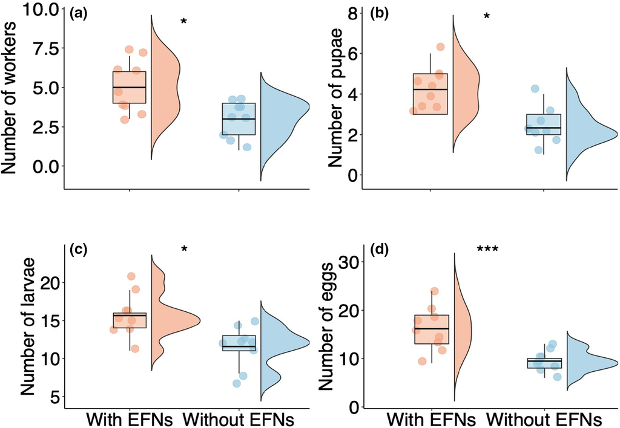

**FIGURE 1**

Number of (a) adult workers, (b) pupae, (c) larvae, and (d) eggs per colony of *Camponotus crassus* ants in the treatments: With extrafloral nectaries (EFNs) and Without EFNs. Figures show a flat violin plot represented by boxplot and Kernel density estimate plot. GLM: **p* < 0.05, ****p* < 0.001

Colonies fed with extrafloral nectar had heavier queens, pupae, larvae, and eggs (Table 2; Figure 2). Adult workers’ weight showed no significant difference between the two treatments (Table 2; Figure 2). Queens (comparing the average of the difference between the final and initial weight), pupae, larvae, and eggs of colonies fed with extrafloral nectar were respectively, 4.7, 1.12, 1.71, and 1.20 times heavier than the individuals of Without EFNs treatment.

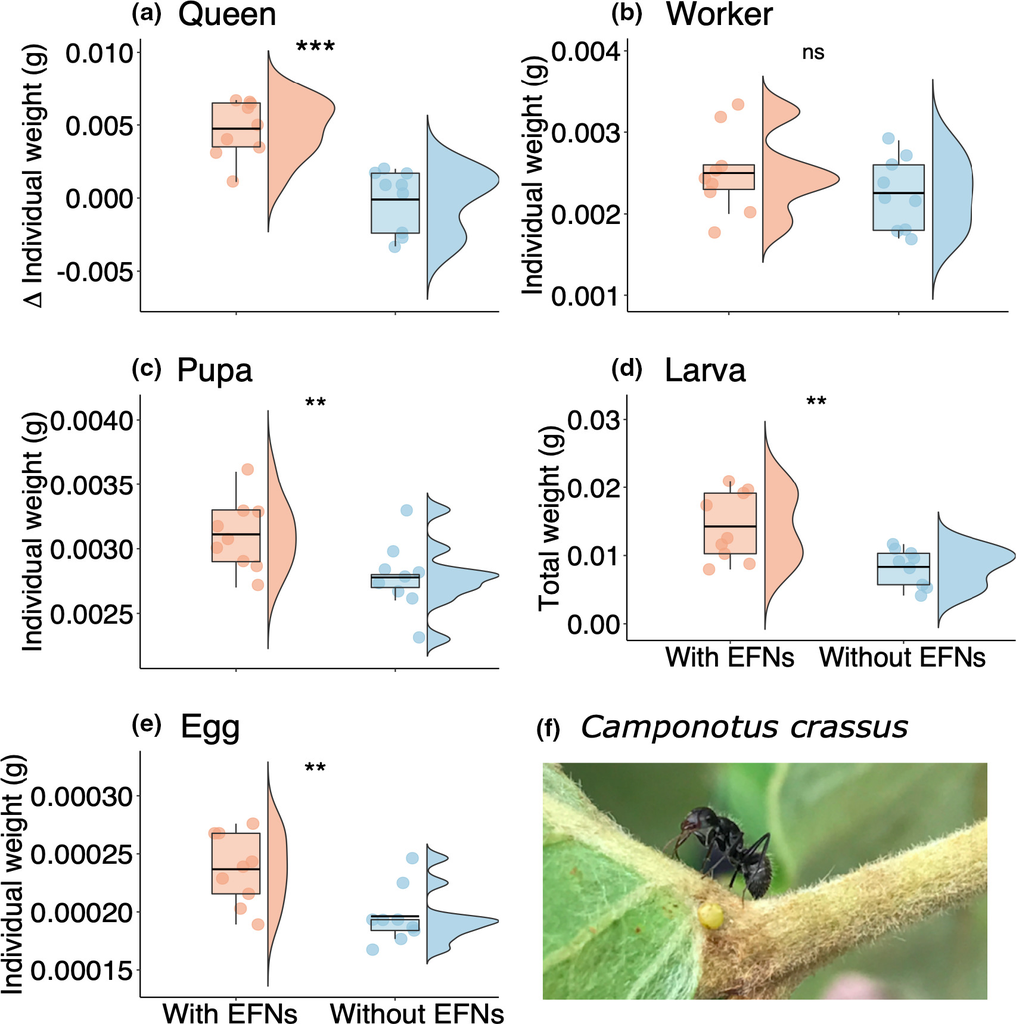

**FIGURE 2**

Mean weight variation for (a) queen, (b) adult worker, (c) pupa, (d) larva, and (e) egg per colony of (f) *Camponotus crassus* ants in the treatments: With extrafloral nectaries (EFNs) and Without EFNs. For a) queens, we used the difference between final and initial weight, and for d) larvae, we used the total weight per colony. Figures show a flat violin plot represented by boxplot and Kernel density estimate plot. GLM: ***p* < 0.01, ****p* < 0.001, ns = non‐significant

Both the total number and weight of individuals per colony differed between the two treatments (Table 2; Figure 3). Colonies that had access to EFNs had 1.5 more individuals and were 2.07 times heavier than the colonies that did not had access.

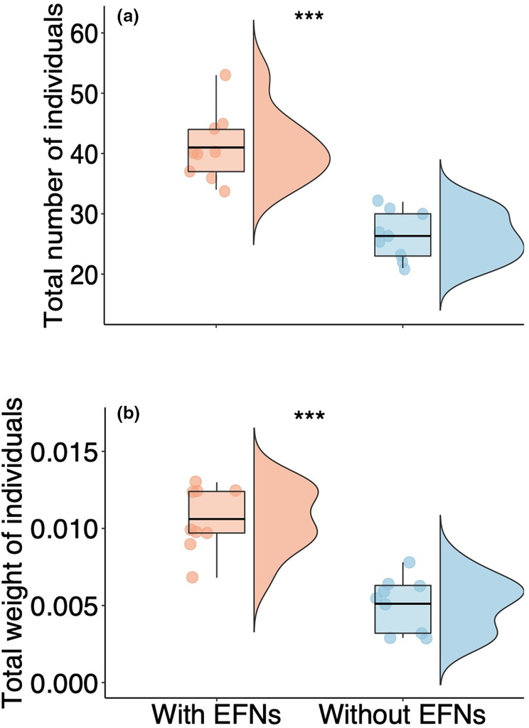

**FIGURE 3**

Total (a) number and (b) weight of individuals (queen, adult workers, pupae, larvae, and eggs) per colony of *Camponotus crassus* ants in the treatments: With extrafloral nectaries (EFNs) and Without EFNs. Figures show a flat violin plot represented by boxplot and Kernel density estimate plot. GLM: ****p* < 0.001

### 3.2 Food resource experiment

On the 30<sup>th</sup> day of analyses, we observed no significant difference in the abundance of adult workers and pupae (Table 3; Figure 4). However, the abundance of larvae and eggs (Table 3) differed among the treatments (Figure 4). The High sugar +insect treatment showed the greatest number of larvae, and eggs, while Low sugar treatment showed the lowest (Table 4).

TABLE 3. GLM results of the effects of different food resources on *Camponotus crassus* colony fitness 30 and 60 days after the beginning of food provision

[output not shown]

### Note

- Significant results (*p*‐value <0.05) are displayed in bold. Degrees of freedom is 3 for all statistic models.

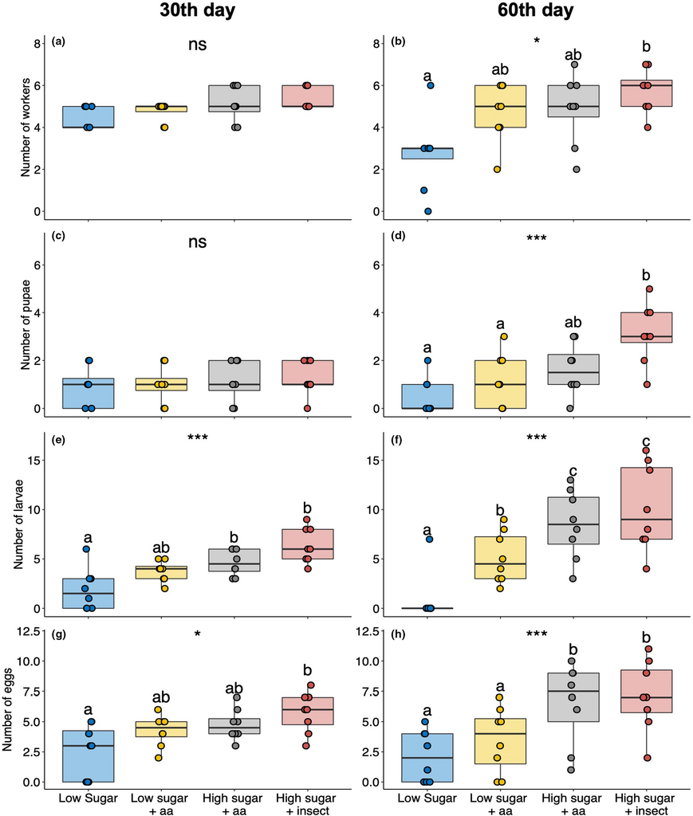

**FIGURE 4**

Number of (a–b) adult workers, (c–d) pupae, (e–f) larvae, and (g–h) eggs per colony of *Camponotus crassus* ants in the four treatments of food resource in the 30<sup>th</sup> and 60<sup>th</sup> day. GLM: **p* < 0.05, ****p* < 0.001, ns—non‐significant. Letters represent statistic difference among treatments by Estimated Marginal Means (EMMs). Figures show median with maximums and minimums

TABLE 4. Mean (± *SD*) number of adult workers, pupae, larvae, and eggs per colony of *Camponotus crassus* ants in the four food resource treatments (eight colonies per treatment) on the 30<sup>th</sup> and 60<sup>th</sup> days

|  | Low sugar | Low sugar +aa | High sugar +aa | High sugar +insect |
| --- | --- | --- | --- | --- |
| 30<sup>th</sup> day |  |  |  |  |
| Workers | 4.37 ± 0.51 | 4.75 ± 0.46 | 5.12 ± 0.83 | 5.37 ± 0.51 |
| Pupae | 0.87 ± 0.83 | 1.00 ± 0.75 | 1.12 ± 0.83 | 1.25 ± 0.70 |
| Larvae | 1.87 ± 2.10 | 3.75 ± 1.03 | 4.62 ± 1.30 | 6.37 ± 1.76 |
| Eggs | 2.50 ± 2.20 | 4.25 ± 1.28 | 4.75 ± 1.28 | 5.75 ± 1.66 |
| 60<sup>th</sup> day |  |  |  |  |
| Workers | 2.75 ± 1.75 | 4.75 ± 1.38 | 4.87 ± 1.64 | 5.75 ± 1.03 |
| Pupae | 0.50 ± 0.75 | 1.12 ± 1.12 | 1.62 ± 1.06 | 3.12 ± 1.24 |
| Larvae | 0.87 ± 2.47 | 5.12 ± 2.58 | 8.50 ± 3.46 | 10.12 ± 4.38 |
| Eggs | 2.12 ± 2.10 | 3.50 ± 2.67 | 6.50 ± 3.33 | 7.12 ± 2.90 |

We observed a significant difference in the number of adult workers, pupae, larvae, and eggs per colony among treatments in the 60<sup>th</sup> day (Table 3; Figure 4). Similarly, the High sugar +insect treatment showed the greatest number of all colony parameters (number of adult workers, pupae, larvae, and eggs) on the 60<sup>th</sup> day, while Low sugar treatment showed the lowest (Table 4).

We found that there was a significant difference in ant colony survival according to the food resource (*χ*<sup>2</sup> = 25.6, *df* = 3, *p* < 0.0001, Figure 5). From a total of eight colonies per treatment used in the experiment, we observed that 50% of Low sugar treatment colonies died in 120 days, while no other colony died in the same period of time. At the end of the analyses (210 days), one (12%) colony of Low sugar group survived, four (50%) of Low sugar +aa, six (75%) of High sugar +aa, and seven (88%) of High sugar +insect (Figure 5).

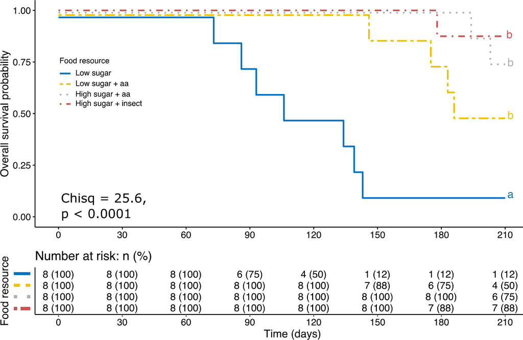

**FIGURE 5**

Colony survival of *Camponotus crassus* ants between the different treatments of food resource. Difference between survival curves was made with G‐rho family followed by log‐rank test (lowercase letter at the right of each survival curve). Survival curves were fitted with the model survfit (Surv(Colony survival +Time)~Group, where colony survival is a dummy variable (1—survived, 0—not survived)

Despite not quantifying the number of eggs and larvae after the 60<sup>th</sup> day of the laboratory experiment, we observed that between 90 and 120 days of experiment the number of eggs and larvae began to decrease in some colonies of Low sugar +aa (ES Calixto, pers. obs.), even though those eggs and larvae were already present. As it was not our aim, we did not properly count the absolute number of these ant castes, but we were aware of their presence, since we needed to check and add food and water frequently, as well as evaluate ant queen survivorship.

## 4 DISCUSSION

The main plant reward to protective mutualistic ants, extrafloral nectar, and carbohydrate‐ and nitrogen‐rich food resources positively impacted ant colony fitness and survival. Our results showed short‐ and long‐term benefits of ant colony fitness (number and weight of individuals) and survival according to specific food resource, consistent with our predictions. In detail, we found that (1) the quality and short‐term supply of extrafloral nectar positively influenced ant colony fitness; and that (2) the short‐ and long‐term supply of more concentrated carbohydrate and nitrogen food resources enhanced the colony fitness and survival compared to nutrient‐poor resources. We presented the first evidence that, in natural extrafloral nectar secretion, the EFN‐mediated ant–plant mutualism is indeed a beneficial interaction (Bronstein, 1998). We have the support of several studies showing that *C. crassus* is an EFN‐plant defender in the Cerrado, including *B. malifolia*, proving that plants are benefited by ants (Alves‐Silva, 2011; Anjos et al., 2017; Fagundes et al., 2017; Lange et al., 2017, 2019), and here, we showed that *C. crassus* colonies do benefit from feeding on extrafloral nectar.

We observed that ant colonies fed on extrafloral nectar presented a greater number and weight of individuals in a short time. This extrafloral nectar is rich in carbohydrates, but also has different diluted compounds, such as lipids, amino acids, enzymes, alkaloids, and phenols (Blüthgen et al., 2004; González‐Teuber & Heil, 2009; Koptur, 1994). According to Davidson (1998), carbohydrates fuel the foraging activities of adult workers, increasing the probability of collecting and/or finding resources, indirectly benefiting the colony. Adequate feeding and development of larvae will result in a significant growth of pupae and adults, and consequently of the colony (Blüthgen & Feldhaar, 2010). For instance, Wheeler (1994) and Nation (2015) showed that lipids and proteins directly benefit queens and brood, since they are required for larval growth, ovary development, and egg production. In this way, colonies fed with extrafloral nectar had greater availability of amino acids, reflected in the weight of the queens and the growth and weight of the colony as a whole.

Colony fitness and survival were influenced by different food resources, in which higher values were found in treatments with high concentration of sugar (High sugar + aa, and High sugar + insect). Each food resource had a certain degree of composition, in which we observed extremely nutritious (High sugar +insect) to non‐nutritive resources (Low sugar). According to Kay et al. (2006), the carbohydrate–protein ratio of the larval ant diet may strongly affect the carbon, nitrogen, and phosphorous levels in larvae and is then reflected in pupae and adults. Also, omnivorous ants can respond dynamically to this carbohydrate–protein balance (Flores‐Flores et al., 2018; Ribeiro et al., 2019), which can affect everything from worker size and mortality, colony growth, and the body mass composition, to foraging behaviors, or even aggressiveness (Blüthgen & Feldhaar, 2010). In this way, the presence of balanced resources to meet the physiological needs of each ant species are fundamental for the colony fitness and survival.

Finally, we expected the Low sugar +aa treatment to have a survival rate similar to the High sugar +aa and High sugar +insect treatments, since at up to 120 days of the experiment, all colonies were alive in three treatments (Figure 5). However, between 90 and 120 days, the number of eggs and larvae began to decrease in some Low sugar +aa colonies, even though those eggs and larvae were previously present (ESC pers. obs.). Although not directly observed, a decrease in brood can indicate cannibalism by the queen due to nutrient imbalance stress. The same behavior was pointed out by Buschinger and Pfeifer (1988), who showed that colonies of *Leptothorax acervorum* (Myrmicinae) on a protein‐deficient diet cannibalized their pupae and larvae (also see Bourke, 1991; Del‐Claro & Tizo‐Pedroso, 2009; Way, 1963). These results show that even with the presence of carbohydrates and amino acids, a specific balance between these compounds is needed to adequately supply the needs of each ant species, as tested by Blüthgen and Fiedler (2004) with a carbohydrate and amino acid preference experiment. Furthermore, when food resource availability changes, some ants can change their foraging behavior and seek different food resources. Anjos et al. (2019) highlighted the role of *Pogonomyrmex naegelii* (Myrmicinae) as seasonal invertebrate carrion removers, showing preference for specific food types at different times of the year (also see Belchior et al., 2012). In another study, Whitford and Jackson (2007) showed that seed harvester ants foraging rates increase at times of low seed availability and high concentrations of prey (alive or dead).

In conclusion, our results show one side of the ant‐EFN‐bearing plant mutualism that has not been evaluated in detail. A large number of studies, including reviews and meta‐analyses (Calixto et al., 2018; Del‐Claro et al., 2016; Rosumek et al., 2009; Trager et al., 2010), have been published on the benefits that ants provide for EFN‐bearing plants, but very few have assessed the other side of the coin. Thus, in addition to showing that there are short‐ and long‐term benefits for ant colony fitness and survival according to specific types of food resources, our study is the first to show that an ant‐EFN‐bearing plant mutualism can be considered a mutualism, where both partners are indeed benefited. We suggest that (i) studies be done evaluating how EFN phenology and other food resources influence the growth and survival of ant colonies over the year. Given that the period of greatest activity of EFNs of the majority of plants of the Cerrado is concentrated in the rainy season (Calixto et al., 2020; Lange et al., 2013; Lange & Del‐Claro, 2014), the colony growth for ants that use this resource should be maximized at this time. We also suggest that (ii) studies be done evaluating how extrafloral nectar from different plants can influence ant colony fitness and survival, since each plant has different levels of extrafloral nectar production and different nutritional contents (Lange et al., 2017).

## ACKNOWLEDGEMENTS

We thank Danilo Borges Santos for earlier comments in the first drafts of the manuscripts, and anonymous reviewers for suggestions and comments; the CCPIU to make available the study area; Isabela Pacheco Borges for carbohydrate and amino acid compounds; Hilda Soares and Rubens Caetano for helping with fieldwork and lab experiments; and Eva Colberg for English review. This study was financed in part by the Coordenação de Aperfeiçoamento de Pessoal de Nível Superior—Brasil (CAPES)—Finance Code 001 (ESC), Conselho Nacional de Pesquisa e Desenvolvimento Tecnológico (CNPq) (KDC), and FAPEMIG (Fundação para o Amparo à Pesquisa de Minas Gerais (KDC).

## CONFLICT OF INTEREST

No potential conflict of interest was reported by the authors.

## AUTHOR CONTRIBUTIONS

Conceptualization—ESC, DL, KDC; formal analysis—ESC; investigation—ESC; methodology—ESC, DL, KDC; supervision—DL, KDC; visualization—ESC, DL, KDC; writing—original draft preparation—ESC; writing—review and editing—ESC, DL, KDC.

## REFERENCES

[figure not shown]

### Details

- © 2021 The Association for Tropical Biology and Conservation

### Research funding

  - Conselho Nacional de Desenvolvimento Científico e Tecnológico

### Keywords

  - [ant colony fitness](https://onlinelibrary.wiley.com/action/doSearch?field1=Keyword&text1=ant%20colony%20fitness)
  - [ant fitness](https://onlinelibrary.wiley.com/action/doSearch?field1=Keyword&text1=ant%20fitness)
  - [ant–plant interaction](https://onlinelibrary.wiley.com/action/doSearch?field1=Keyword&text1=ant%E2%80%93plant%20interaction)
  - Brazil
  - [*Camponotus crassus*](https://onlinelibrary.wiley.com/action/doSearch?field1=Keyword&text1=%0ACamponotus%20crassus%0A)
  - Cerrado

### Publication History

  - Version of Record online: 08 February 2021
  - Manuscript accepted: 12 December 2020
  - Manuscript revised: 19 November 2020
  - Manuscript received: 29 June 2020